# Non-parametric Bayes tutorial

```r
library(ggplot2)
library(ggtern)          # to construct ternary plots
library(LearnBayes)      # to use the rdirichlet() function
library(gridExtra)
```

# Beta distribution

- We will look at the influence of shape parameters $a$, $b$ on distribution of mass on the interval $[0,1]$.
- If $\rho \sim Beta(a,b)$, then the sample point $\rho$ can be interpreted as a probability.
- Corresponding to every draw $\rho$ from $Beta(a,b)$ for $a,b>0$ there exists a corresponding pmf $Bern(\rho)$. The converse correspondence holds as well. So, this is a one-to-one correspondence.
- So a draw from $Beta(a,b)$ can be interpreted as probability of one of two possible categories. Values of $a$ and $b$ determine the chance of observing 1 and 2 respectively.

```r
param_vals = seq(0,1, by = 0.01)
```

- Case1: $a\geq 1$, $b\geq 1$ and $a\leq b$
  - When $a<b$, we notice that $\rho$ tends to be smaller. This means that category one is less likely to occur in comparision to that of category 2.

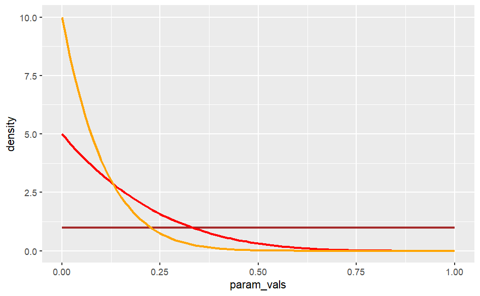

```r
# fix a value
a = 1
ab11 = dbeta(param_vals, shape1 = a, shape2 = 1)
ab15 = dbeta(param_vals, shape1 = a, shape2 = 5)
ab1_10 = dbeta(param_vals, shape1 = a, shape2 = 10)

ggplot(mapping = aes(x = param_vals)) +
  geom_line(mapping = aes(y = ab11), color = "brown", linewidth = 1) +
  geom_line(mapping = aes(y = ab15), color = "red", linewidth = 1) +
  geom_line(mapping = aes(y = ab1_10), color = "orange", linewidth = 1) +
  ylab("density")
```

Case2: $a\geq1$, $b\geq 1$ and $a\geq b$ * When $a\geqb$, we notice that $\rho$ tends to be larger. This means that category one is more likely to occur in comparison to that of category 2.

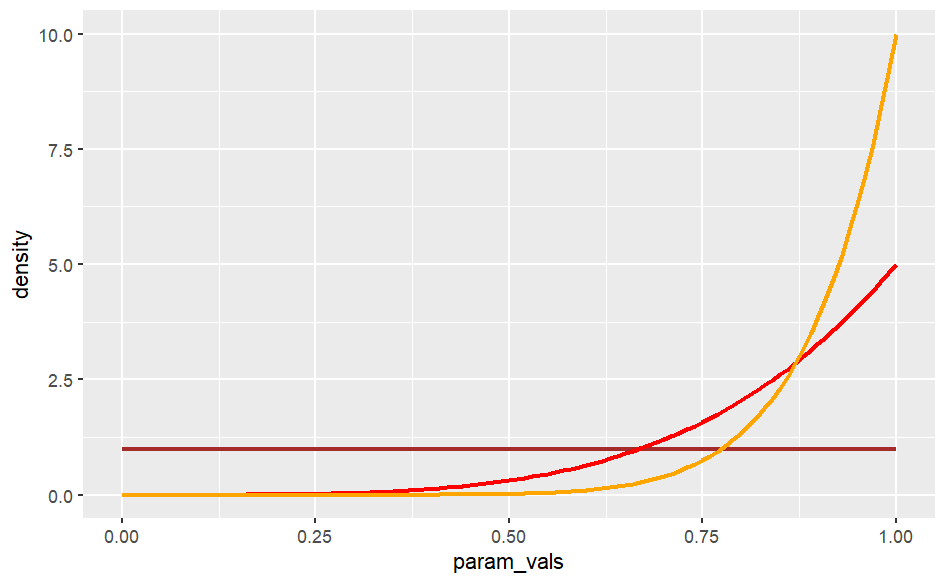

```r
# fix a value
b = 1
ab11 = dbeta(param_vals, shape1 = 1, shape2 = b)
ab51 = dbeta(param_vals, shape1 = 5, shape2 = b)
ab10_1 = dbeta(param_vals, shape1 = 10, shape2 = b)

ggplot(mapping = aes(x = param_vals)) +
  geom_line(mapping = aes(y = ab11), color = "brown", linewidth = 1) +
  geom_line(mapping = aes(y = ab51), color = "red", linewidth = 1) +
  geom_line(mapping = aes(y = ab10_1), color = "orange", linewidth = 1) +
  ylab("density")
```

Case3: $a\geq1$, $b\geq 1$ and $a=b$ Beta density is symmetric about $0.5$ when $a = b$ and $a, b \geq 1$. Since $a, b$ control probability of categories 1 and 2, we see that the density gets more and more peaked at $0.5$ as $a,b$ values increase.

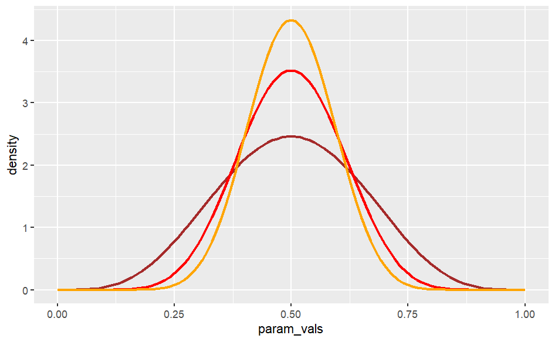

```r
# fix a value
ab55 = dbeta(param_vals, shape1 = 5, shape2 = 5)
ab10_10 = dbeta(param_vals, shape1 = 10, shape2 = 10)
ab15_15 = dbeta(param_vals, shape1 = 15, shape2 = 15)

ggplot(mapping = aes(x = param_vals)) +
  geom_line(mapping = aes(y = ab55), color = "brown", linewidth = 1) +
  geom_line(mapping = aes(y = ab10_10), color = "red", linewidth = 1) +
  geom_line(mapping = aes(y = ab15_15), color = "orange", linewidth = 1) +
  ylab("density")
```

Case 4: $a<b$ and $a,b>1$: Density has a peak if both a and b are strictly more than 1. The densities are skewed such that probability of category 1 is on the lower side.

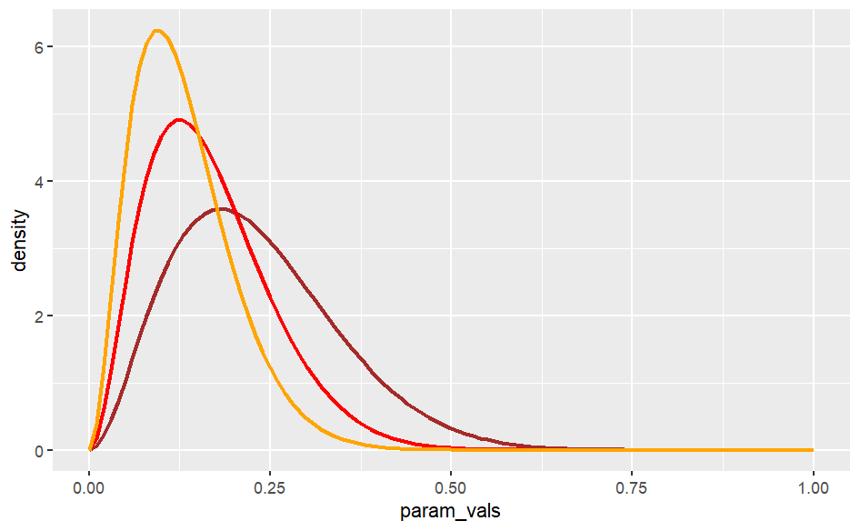

```r
# fix a value
ab58 = dbeta(param_vals, shape1 = 3, shape2 = 10)
ab10_12 = dbeta(param_vals, shape1 = 3, shape2 = 15)
ab15_17 = dbeta(param_vals, shape1 = 3, shape2 = 20)

ggplot(mapping = aes(x = param_vals)) +
  geom_line(mapping = aes(y = ab58), color = "brown", linewidth = 1) +
  geom_line(mapping = aes(y = ab10_12), color = "red", linewidth = 1) +
  geom_line(mapping = aes(y = ab15_17), color = "orange", linewidth = 1) +
  ylab("density")
```

Case 5: $a<b$ and $a < 1$ and $b \geq1$:

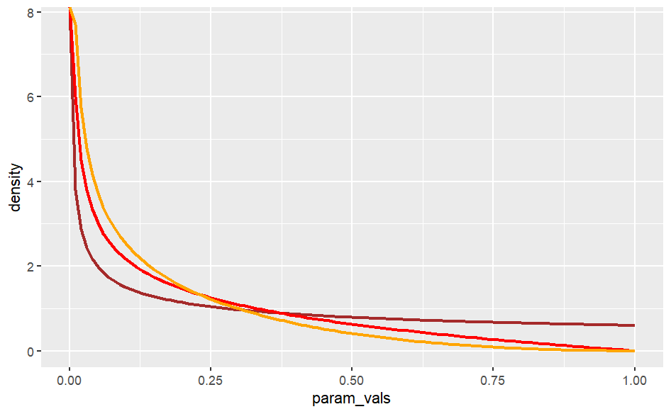

```r
# fix a value
ab58 = dbeta(param_vals, shape1 = 0.6, shape2 = 1)
ab10_12 = dbeta(param_vals, shape1 = 0.6, shape2 = 2)
ab15_17 = dbeta(param_vals, shape1 = 0.6, shape2 = 3)

ggplot(mapping = aes(x = param_vals)) +
  geom_line(mapping = aes(y = ab58), color = "brown", linewidth = 1) +
  geom_line(mapping = aes(y = ab10_12), color = "red", linewidth = 1) +
  geom_line(mapping = aes(y = ab15_17), color = "orange", linewidth = 1) +
  ylab("density")
```

Case 6: $a>b$ and $a \geq 1$ and $b < 1$:

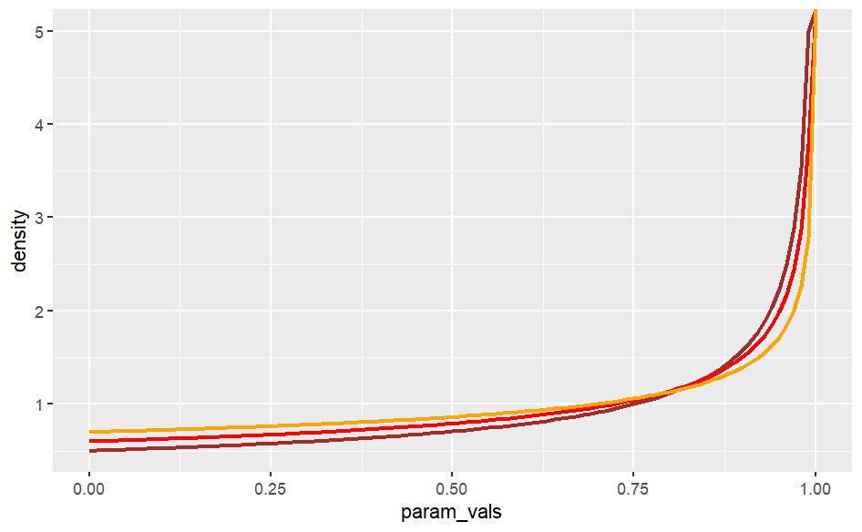

```r
# fix a value
ab58 = dbeta(param_vals, shape1 = 1, shape2 = 0.5)
ab10_12 = dbeta(param_vals, shape1 = 1, shape2 = 0.6)
ab15_17 = dbeta(param_vals, shape1 = 1, shape2 = 0.7)

ggplot(mapping = aes(x = param_vals)) +
  geom_line(mapping = aes(y = ab58), color = "brown", linewidth = 1) +
  geom_line(mapping = aes(y = ab10_12), color = "red", linewidth = 1) +
  geom_line(mapping = aes(y = ab15_17), color = "orange", linewidth = 1) +
  ylab("density")
```

Case 7: $a>b$ and $a, b < 1 $:

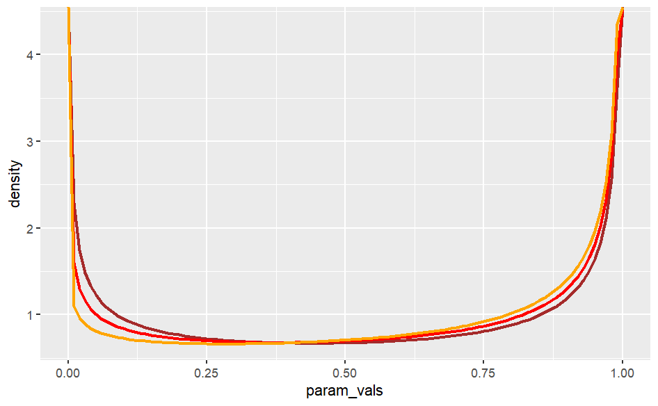

```r
# fix a value
ab58 = dbeta(param_vals, shape1 = 0.6, shape2 = 0.5)
ab10_12 = dbeta(param_vals, shape1 = 0.7, shape2 = 0.5)
ab15_17 = dbeta(param_vals, shape1 = 0.8, shape2 = 0.5)

ggplot(mapping = aes(x = param_vals)) +
  geom_line(mapping = aes(y = ab58), color = "brown", linewidth = 1) +
  geom_line(mapping = aes(y = ab10_12), color = "red", linewidth = 1) +
  geom_line(mapping = aes(y = ab15_17), color = "orange", linewidth = 1) +
  ylab("density")
```

Case 8: $a<b$ and $a, b < 1 $:

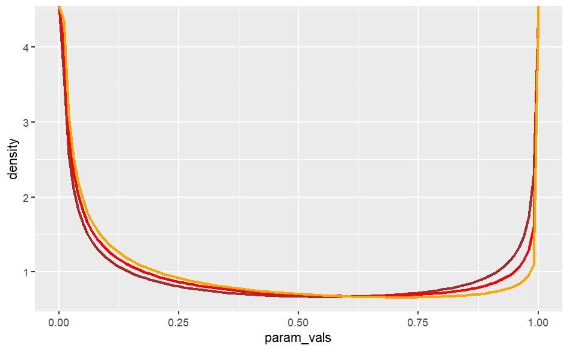

```r
# fix a value
ab58 = dbeta(param_vals, shape1 = 0.5, shape2 = 0.6)
ab10_12 = dbeta(param_vals, shape1 = 0.5, shape2 = 0.7)
ab15_17 = dbeta(param_vals, shape1 = 0.5, shape2 = 0.8)

ggplot(mapping = aes(x = param_vals)) +
  geom_line(mapping = aes(y = ab58), color = "brown", linewidth = 1) +
  geom_line(mapping = aes(y = ab10_12), color = "red", linewidth = 1) +
  geom_line(mapping = aes(y = ab15_17), color = "orange", linewidth = 1) +
  ylab("density")
```

Case 9: $a=b$ and $a, b < 1 $:

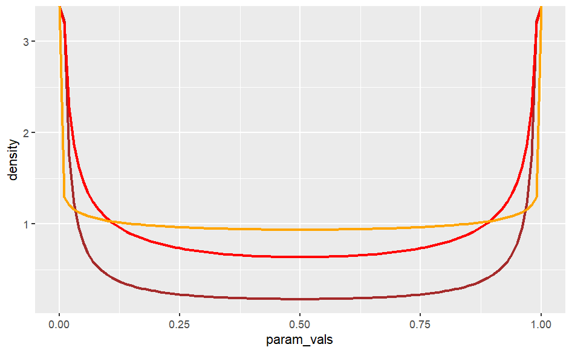

```r
# fix a value
ab58 = dbeta(param_vals, shape1 = 0.1, shape2 = 0.1)
ab10_12 = dbeta(param_vals, shape1 = 0.5, shape2 = 0.5)
ab15_17 = dbeta(param_vals, shape1 = 0.9, shape2 = 0.9)

ggplot(mapping = aes(x = param_vals)) +
  geom_line(mapping = aes(y = ab58), color = "brown", linewidth = 1) +
  geom_line(mapping = aes(y = ab10_12), color = "red", linewidth = 1) +
  geom_line(mapping = aes(y = ab15_17), color = "orange", linewidth = 1) +
  ylab("density")
```

Function to draw a sample from Beta distribution

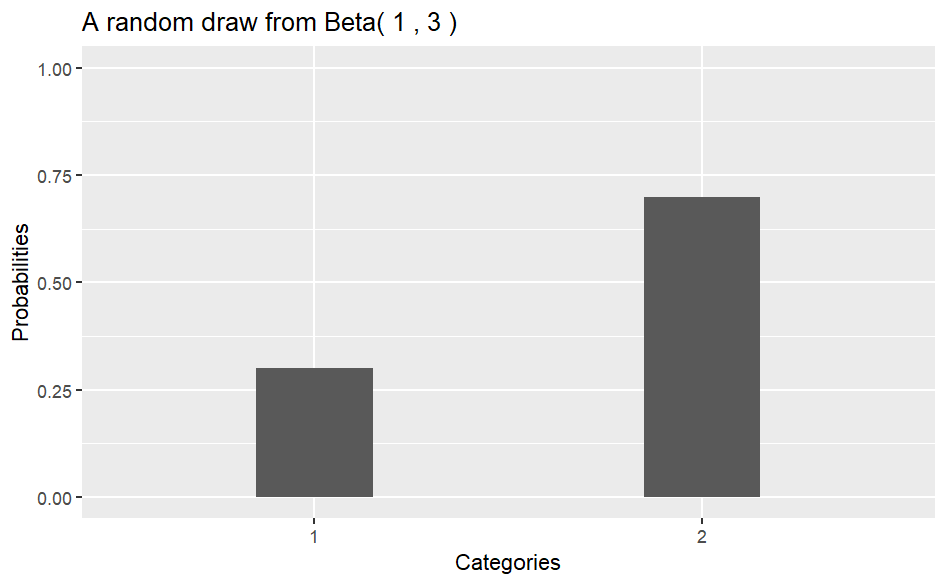

```r
sample_pt = rbeta(1, 1, 3)
sample_beta <- function(a,b){
  p <- ggplot() +
        geom_bar(mapping = aes(x = as.factor(c(1,2)), y = c(sample_pt, 1-sample_pt)), stat = "identity", width = 0.3) +
        xlab("Categories") +
        ylab("Probabilities") +
        ggtitle(paste("A random draw from Beta(",a,",",b,")"))+
        scale_y_continuous(limits = c(0, 1))
  return(p)
}

sample_beta(1,3)
```

# Dirichlet Distribution

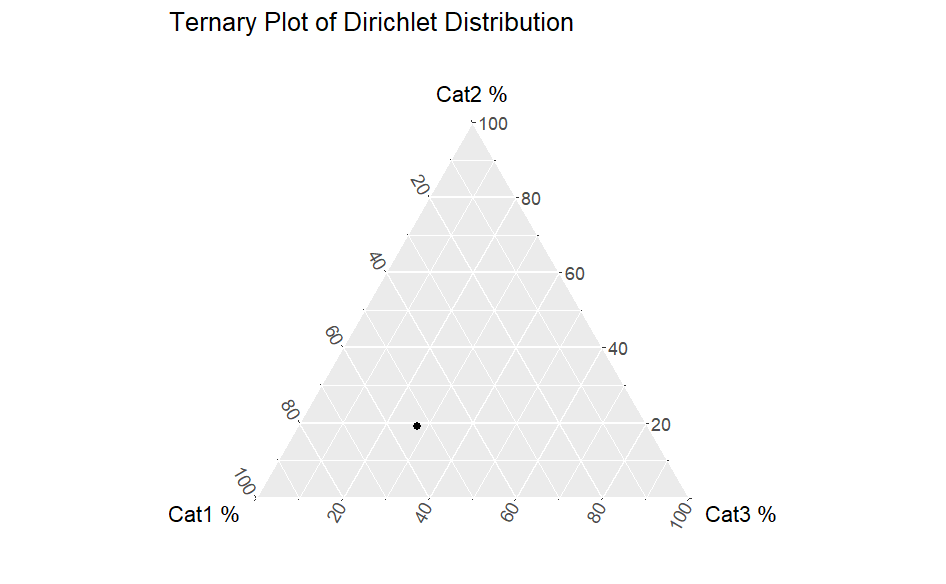

```r
alpha <- c(2, 2, 2)  # Dirichlet parameters
N <- 1  # Number of samples

data <- as.data.frame(rdirichlet(N, alpha))
colnames(data) <- c("Cat1", "Cat2", "Cat3") # name the three categories

# Create a ternary plot
ggtern(data = data, aes(x = Cat1, y = Cat2, z = Cat3)) +
  geom_point() +
  labs(title = "Ternary Plot of Dirichlet Distribution",
       x = "Cat1 %",
       y = "Cat2 %",
       z = "Cat3 %")
```

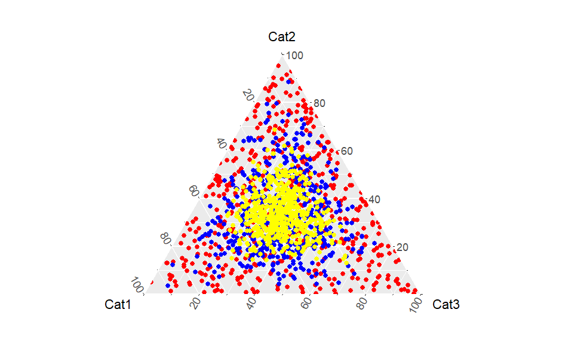

```r
alpha1 <- c(1, 1, 1)  # Dirichlet parameters
alpha3 <- c(3,3,3)
alpha8 <- c(8,8,8)
N <- 500  # Number of samples

data1 <- as.data.frame(rdirichlet(N, alpha1))
data3 <- as.data.frame(rdirichlet(N, alpha3))
data8 <- as.data.frame(rdirichlet(N, alpha8))

# name the three categories
colnames(data1) <- c("Cat1", "Cat2", "Cat3")
colnames(data3) <- c("Cat1", "Cat2", "Cat3")
colnames(data8) <- c("Cat1", "Cat2", "Cat3")

# Create a ternary plot
ggtern(mapping = aes(x = Cat1, y = Cat2, z = Cat3)) +
        geom_point(data = data1, color = "red") +
        geom_point(data = data3, color = "blue") +
        geom_point(data = data8, color = "yellow")
```

```r
        labs(title = "Ternary Plot of Dirichlet Distribution",
            x = "Cat1 %",
            y = "Cat2 %",
            z = "Cat3 %")
```

```
$x
[1] "Cat1 %"

$y
[1] "Cat2 %"

$z
[1] "Cat3 %"

$title
[1] "Ternary Plot of Dirichlet Distribution"

attr(,"class")
[1] "labels"
```

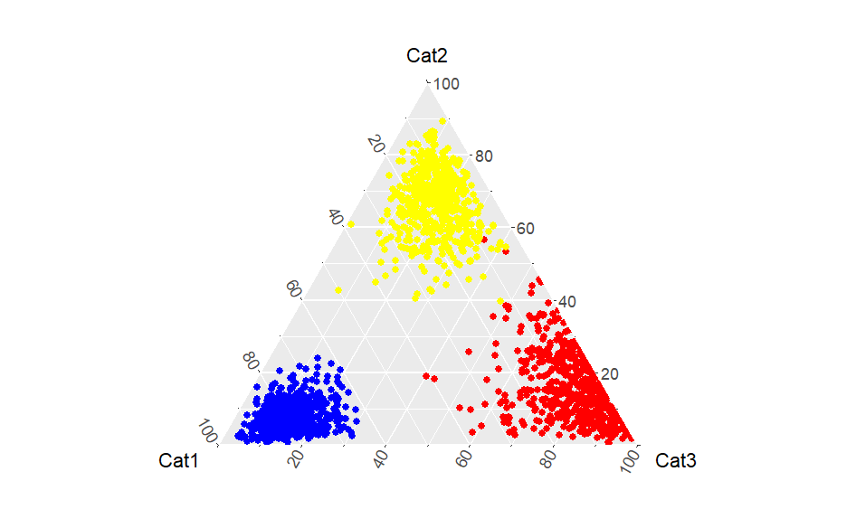

```r
alpha1 <- c(1, 2, 10)  # Dirichlet parameters
alpha3 <- c(30,3,5)
alpha8 <- c(4,18,5)
N <- 500  # Number of samples

data1 <- as.data.frame(rdirichlet(N, alpha1))
data3 <- as.data.frame(rdirichlet(N, alpha3))
data8 <- as.data.frame(rdirichlet(N, alpha8))

# name the three categories
colnames(data1) <- c("Cat1", "Cat2", "Cat3")
colnames(data3) <- c("Cat1", "Cat2", "Cat3")
colnames(data8) <- c("Cat1", "Cat2", "Cat3")

# Create a ternary plot
ggtern(mapping = aes(x = Cat1, y = Cat2, z = Cat3)) +
        geom_point(data = data1, color = "red") +
        geom_point(data = data3, color = "blue") +
        geom_point(data = data8, color = "yellow")
```

```r
        labs(title = "Ternary Plot of Dirichlet Distribution",
            x = "Cat1 %",
            y = "Cat2 %",
            z = "Cat3 %")
```

```
$x
[1] "Cat1 %"

$y
[1] "Cat2 %"

$z
[1] "Cat3 %"

$title
[1] "Ternary Plot of Dirichlet Distribution"

attr(,"class")
[1] "labels"
```

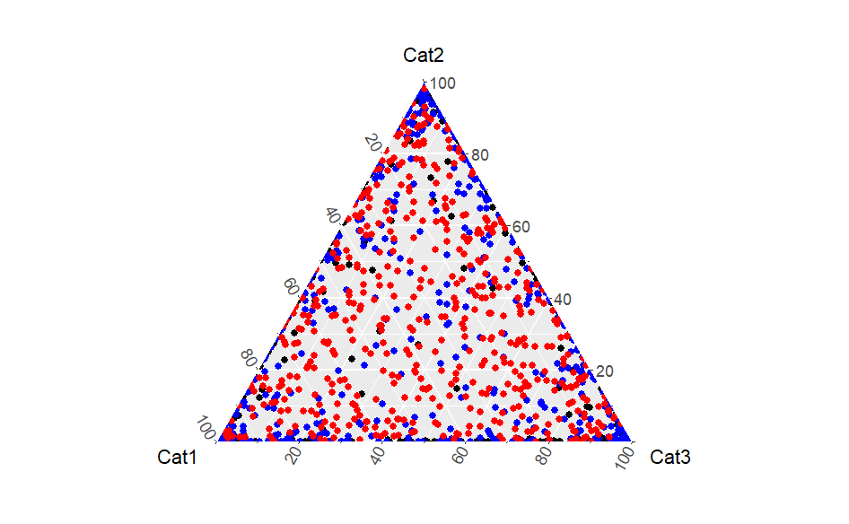

```r
alpha1 <- c(0.1, 0.1, 0.1)  # Dirichlet parameters
alpha3 <- c(0.3,0.3,0.3)
alpha8 <- c(0.8,0.8,0.8)
N <- 500  # Number of samples

data1 <- as.data.frame(rdirichlet(N, alpha1))
data3 <- as.data.frame(rdirichlet(N, alpha3))
data8 <- as.data.frame(rdirichlet(N, alpha8))

# name the three categories
colnames(data1) <- c("Cat1", "Cat2", "Cat3")
colnames(data3) <- c("Cat1", "Cat2", "Cat3")
colnames(data8) <- c("Cat1", "Cat2", "Cat3")

# Create a ternary plot
ggtern(mapping = aes(x = Cat1, y = Cat2, z = Cat3)) +
        geom_point(data = data1, color = "black") +
        geom_point(data = data3, color = "blue") +
        geom_point(data = data8, color = "red")
```

```r
        labs(title = "Ternary Plot of Dirichlet Distribution",
            x = "Cat1 %",
            y = "Cat2 %",
            z = "Cat3 %")
```

```
$x
[1] "Cat1 %"

$y
[1] "Cat2 %"

$z
[1] "Cat3 %"

$title
[1] "Ternary Plot of Dirichlet Distribution"

attr(,"class")
[1] "labels"
```

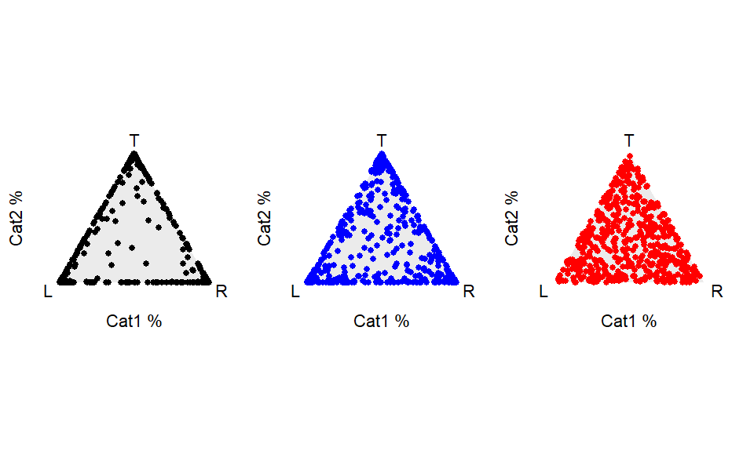

```r
p1 <- ggtern(mapping = aes(x = Cat1, y = Cat2, z = Cat3)) +
        geom_point(data = data1, color = "black") +
        labs(x = "Cat1 %",
            y = "Cat2 %",
            z = "Cat3 %")

p2 <- ggtern(mapping = aes(x = Cat1, y = Cat2, z = Cat3)) +
        geom_point(data = data3, color = "blue") +
        labs(x = "Cat1 %",
            y = "Cat2 %",
            z = "Cat3 %")

p3 <- ggtern(mapping = aes(x = Cat1, y = Cat2, z = Cat3)) +
        geom_point(data = data8, color = "red") +
        labs(x = "Cat1 %",
            y = "Cat2 %",
            z = "Cat3 %")

grid.arrange(p1, p2, p3, nrow = 1)
```

[figure not shown]

# What if K > N?

- More clusters than data points. This means that there will be empty clusters.